# Global Findex Database - Understanding Financial Services and Inclusion

Hiba Hassan-hibah

2022-12-16

## Introduction-Global Findex Database

This project aims at identifying some key trends in the financial services industry and their subsequent acceptance/adoption by communities across the globe.

This rich dataset: - identifies the kind of financial services available (banking, mobile wallets, digital payments) - adoption and resistance to these financial services across different regions, globally for the year 2021

Through the course of analysis, we identify these trends and subsequently give policy recommendations on how such services may be improved to encourage both quality enhancement and financial inclusivity.

About the dataset: 1) The dataset utilized is World Bank - Global Financial Inclusion (Global Findex) Database 2021: https://microdata.worldbank.org/index.php/catalog/4607/get-microdata 2) The data was cleaned and irrelevant columns were dropped, some missing values were replaced by the mode of that country/factor - this is the data set that was utilized finally (can be found attached as an excel and csv format file)

## Importing data

```r
GFI <- read.csv("C:/CMU/Post-CMU/Fall 2022/94842-Programming with R/Project/GFI/Global Financial Index Data2 - hibah.csv", stringsAsFactors=TRUE)
```

## Initial Data Analysis

```r
summary(GFI)
```

```
##                Country        Country.Code
##  China             :  3500   CHN    :  3500
##  India             :  3000   IND    :  3000
##  Russian Federation:  2011   RUS    :  2011
##  Indonesia         :  1062   IDN    :  1062
##  Lebanon           :  1022   LBN    :  1022
##  Gabon             :  1020   GAB    :  1020
##  (Other)           :116239   (Other):116239
##                                                 Region        pop_adult
##  High income: OECD                                 :32593   Min.   :2.952e+05
##  Sub-Saharan Africa (excluding high income)        :25037   1st Qu.:4.670e+06
##  Europe & Central Asia (excluding high income)     :18022   Median :9.612e+06
##  Latin America & Caribbean (excluding high income) :14519   Mean   :8.052e+07
##  East Asia & Pacific (excluding high income)       :11579   3rd Qu.:3.372e+07
##  Middle East & North Africa (excluding high income): 9053   Max.   :1.154e+09
##  (Other)                                           :17051
##   wpid_random             wgt            Gender           age
##  Min.   :111113978   Min.   :0.1317   Female:60241   Min.   :15.00
##  1st Qu.:136254674   1st Qu.:0.4399   Male  :67613   1st Qu.:27.00
##  Median :161286675   Median :0.7572                  Median :39.00
##  Mean   :161202781   Mean   :1.0000                  Mean   :41.71
##  3rd Qu.:186217008   3rd Qu.:1.2761                  3rd Qu.:55.00
##  Max.   :211110199   Max.   :6.2457                  Max.   :99.00
##                                                      NA's   :455
##       educ           inc_q           emp_in      urbanicity_f2f
##  Min.   :1.000   Min.   :1.000   Min.   :0.000   Min.   :1.00
##  1st Qu.:2.000   1st Qu.:2.000   1st Qu.:0.000   1st Qu.:1.00
##  Median :2.000   Median :3.000   Median :1.000   Median :1.00
##  Mean   :2.008   Mean   :3.238   Mean   :0.662   Mean   :1.44
##  3rd Qu.:2.000   3rd Qu.:5.000   3rd Qu.:1.000   3rd Qu.:2.00
##  Max.   :5.000   Max.   :5.000   Max.   :1.000   Max.   :2.00
##                                  NA's   :3502    NA's   :68243
##     account        account_fin      account_mob    Bank.Account.Ownership
##  Min.   :0.0000   Min.   :0.0000   Min.   :0.00    Min.   :1.000
##  1st Qu.:0.0000   1st Qu.:0.0000   1st Qu.:0.00    1st Qu.:1.000
##  Median :1.0000   Median :1.0000   Median :0.00    Median :1.000
##  Mean   :0.7434   Mean   :0.6932   Mean   :0.27    Mean   :1.455
##  3rd Qu.:1.0000   3rd Qu.:1.0000   3rd Qu.:1.00    3rd Qu.:2.000
##  Max.   :1.0000   Max.   :1.0000   Max.   :1.00    Max.   :4.000
##                                    NA's   :59173
```

[output cut: 113 more lines]

```
##  Min.   :1.000   Min.   :1.000       Min.   :1.000   Min.   :1.000
##  1st Qu.:4.000   1st Qu.:4.000       1st Qu.:1.000   1st Qu.:2.000
##  Median :4.000   Median :4.000       Median :2.000   Median :5.000
##  Mean   :3.664   Mean   :3.741       Mean   :2.499   Mean   :3.697
##  3rd Qu.:4.000   3rd Qu.:4.000       3rd Qu.:4.000   3rd Qu.:5.000
##  Max.   :5.000   Max.   :5.000       Max.   :5.000   Max.   :6.000
##                  NA's   :29606                       NA's   :29606
##   mobileowner    internetaccess
##  Min.   :1.000   Min.   :1.000
##  1st Qu.:1.000   1st Qu.:1.000
##  Median :1.000   Median :1.000
##  Mean   :1.103   Mean   :1.274
##  3rd Qu.:1.000   3rd Qu.:2.000
##  Max.   :4.000   Max.   :4.000
##
```

```r
nrow(GFI)
```

```
## [1] 127854
```

```r
ncol(GFI)
```

```
## [1] 64
```

```r
dim(GFI)
```

```
## [1] 127854     64
```

## Overall Data Story Analysis

Now we do smaller analysis regarding things like internet access, mobile phone access, bank account usage to better understand the kind of data set we are dealing with and see what kind of financial services are picking pace/have potential for improvement in specific regions and eventually country-wise analysis.

```r
#understanding demographics
summary(GFI$age, GFI$Gender, GFI$educ)
```

```
##    Min. 1st Qu.  Median    Mean 3rd Qu.    Max.    NA's
##   15.00   27.00   39.00   41.71   55.00   99.00     455
```

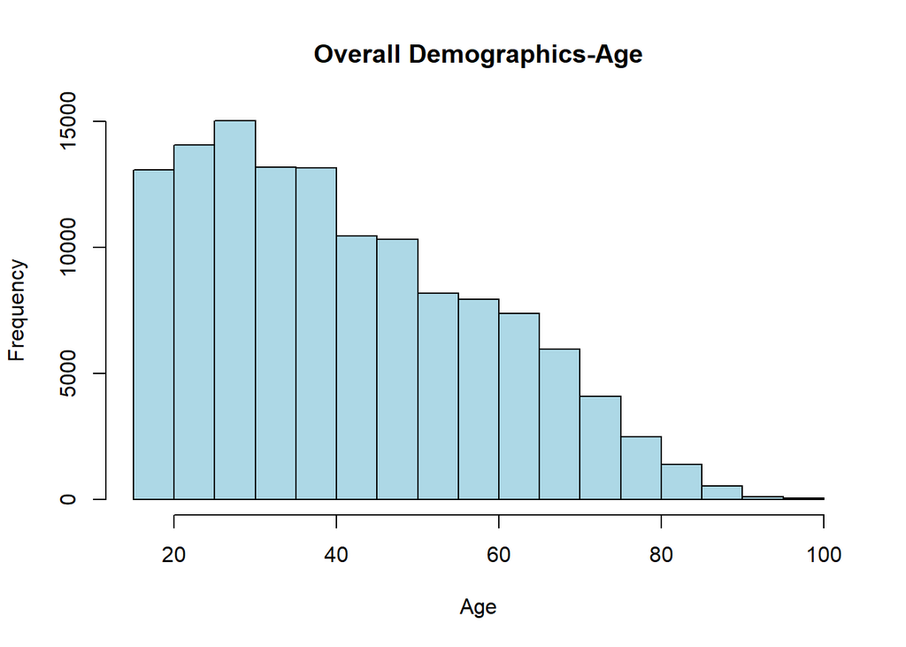

```r
hist(GFI$age,
         main = "Overall Demographics-Age",
         xlab = "Age",
         col = "light blue")
```

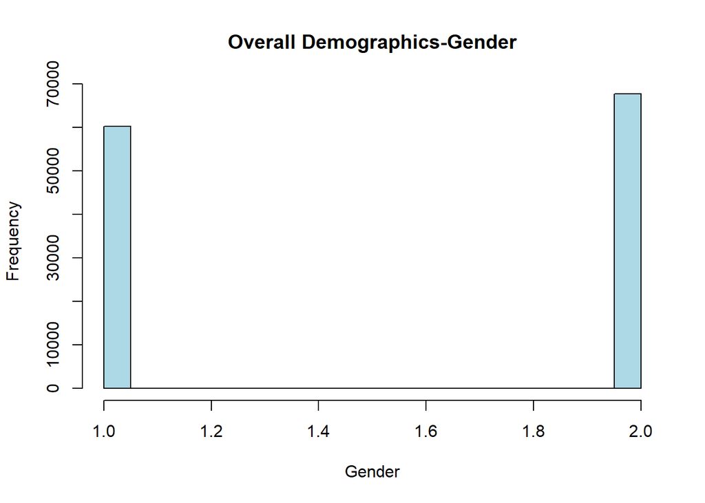

```r
hist(as.numeric(GFI$Gender),
         main = "Overall Demographics-Gender",
         xlab = "Gender",
         col = "light blue")
```

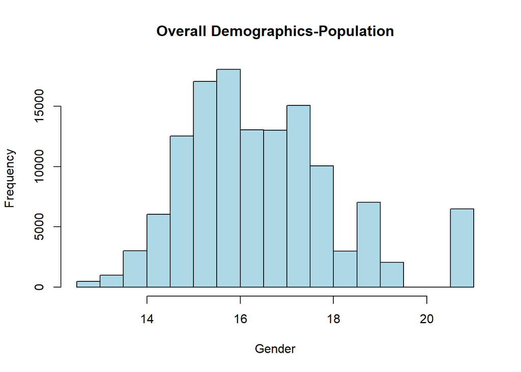

```r
hist(log(GFI$pop_adult),
         main = "Overall Demographics-Population",
         xlab = "Gender",
         col = "light blue")
```

A major chunk of the individuals are males(coded as 2), young adults aged between 18 to 40.

```r
#understanding internet access across different regions
table(GFI$Region, GFI$internetaccess)
```

```
##
##                                                          1     2     3     4
##                                                        963    37     0     0
##   East Asia & Pacific (excluding high income)         9283  2271    20     5
##   Europe & Central Asia (excluding high income)      14678  3266    14    64
##   High income: nonOECD                                7131   903     4     4
##   High income: OECD                                  30346  2207    22    18
##   Latin America & Caribbean (excluding high income)  10693  3753    15    58
##   Middle East & North Africa (excluding high income)  6956  2077     6    14
##   South Asia                                          2879  5084    45     1
##   Sub-Saharan Africa (excluding high income)         10622 14228   158    29
```

We observe that majority of the regions do have access to internet - as most responses come out to be 1 ie ‘Yes’. Regions like Europe,OECD and Latin America have higher internet access compared to regions like South Asia and Africa.

As an initial analysis based on this, we can assume that ease of internet access may help encourage use of digital financial services.

```r
#understanding mobile phone access across different regions
table(GFI$Region, GFI$mobileowner)
```

```
##
##                                                          1     2     3     4
##                                                        990    10     0     0
##   East Asia & Pacific (excluding high income)        10766   807     2     4
##   Europe & Central Asia (excluding high income)      16910  1092     3    17
##   High income: nonOECD                                7840   199     1     2
##   High income: OECD                                  31549  1034     7     3
##   Latin America & Caribbean (excluding high income)  12926  1550     3    40
##   Middle East & North Africa (excluding high income)  8403   644     1     5
##   South Asia                                          6049  1956     1     3
##   Sub-Saharan Africa (excluding high income)         19447  5564    10    16
```

[figure not shown]

```r
#mobile phone access overall
hist(GFI$Bank.Account.Ownership, main = "Overall Mobile Phone Access",
     xlab = "Mobile Phone Access Response")
```

Similar to the analysis of internet access, we see Europe, Latin America and OECD seem to have higher mobile ownership compared to regions like South Asia and Africa. A key thing to note is that these regions do not include high income individuals therefore, the analysis can deduce that mobile access in low to middle income communities can be key in terms of access and use of digital financial services like mobile money services.

```r
#understanding bank ownership across regions
table(GFI$Region, GFI$Bank.Account.Ownership)
```

```
##
##                                                          1     2     3     4
##                                                          0  1000     0     0
##   East Asia & Pacific (excluding high income)         6042  5397   135     5
##   Europe & Central Asia (excluding high income)      11464  6473    79     6
##   High income: nonOECD                                5968  2032    42     0
##   High income: OECD                                  16934 15540   112     7
##   Latin America & Caribbean (excluding high income)   8754  5743    12    10
##   Middle East & North Africa (excluding high income)  5508  3540     5     0
##   South Asia                                          3734  4199    35    41
##   Sub-Saharan Africa (excluding high income)         12004 12922    96    15
```

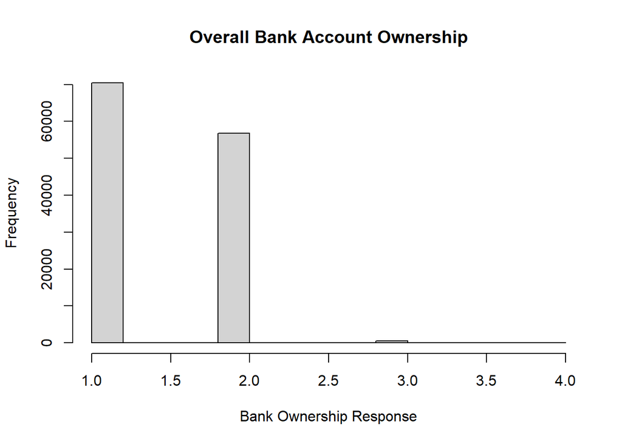

```r
#bank ownership overall
hist(GFI$Bank.Account.Ownership, main = "Overall Bank Account Ownership",
     xlab = "Bank Ownership Response")
```

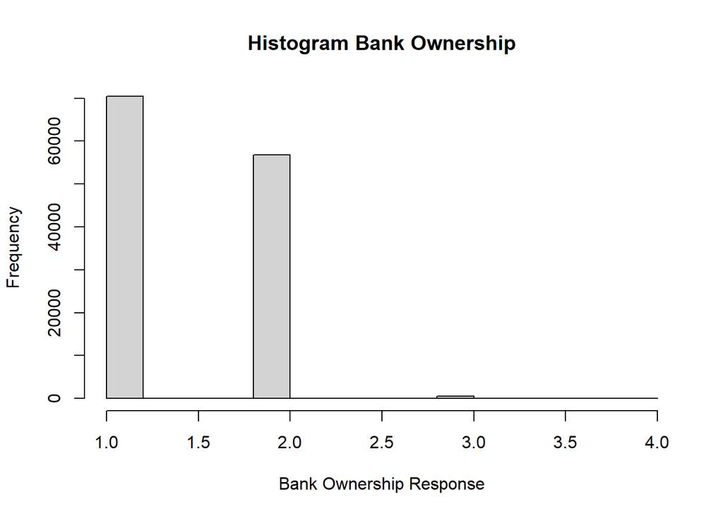

```r
#understanding bank ownership across regions
hist(GFI$Bank.Account.Ownership, main = "Histogram Bank Ownership",
     xlab = "Bank Ownership Response")
```

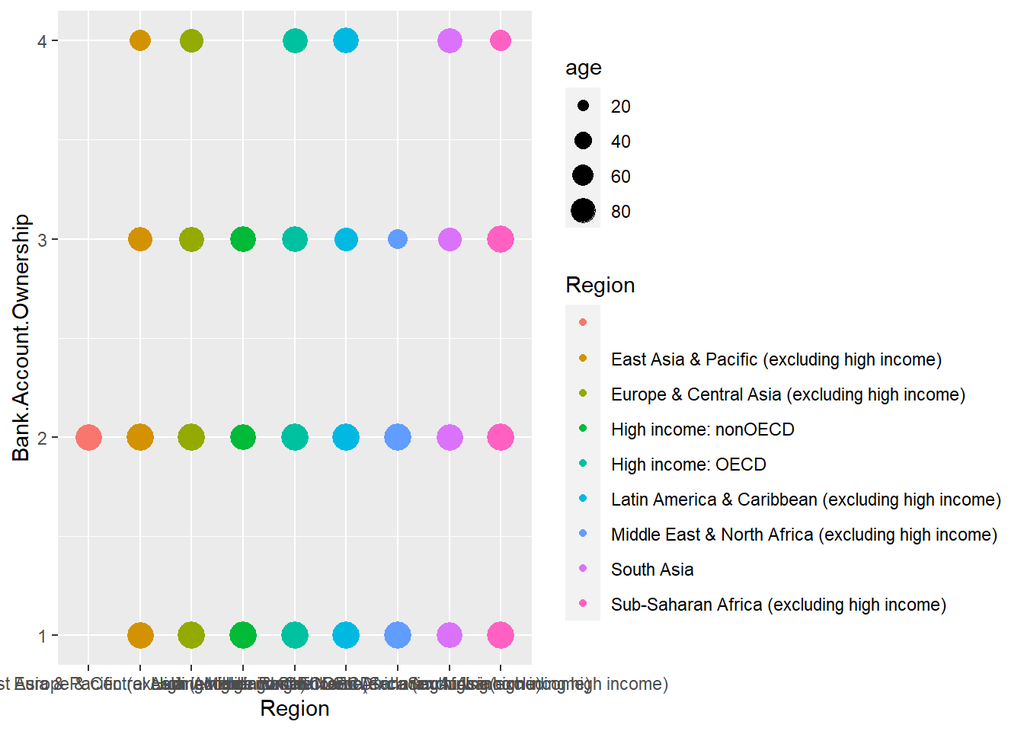

```r
#Spread of financial services across region and age
GFI.plot <- ggplot(data=GFI, aes(x=Region, y=Bank.Account.Ownership))
ggplot(data=GFI, aes(x=Region, y=Bank.Account.Ownership, color=Region))+geom_point(aes(size=age))+facet_grid()
```

```r
#theme(axis.text.x = element_text(angle=45)) - I wanted to use this to fix the axis but it hides the age legend
```

## Mobile Money Financial Services

Now, we focus on one key financial service ie Mobile Money Market - within this segment of the analysis we focus on understanding the following dimensions: 1) How well has the mobile money market integrated itself so far 2) Correlation between internet access and usage of mobile money market financial services

```r
summary(GFI$mobileowner)
```

```
##    Min. 1st Qu.  Median    Mean 3rd Qu.    Max.
##   1.000   1.000   1.000   1.103   1.000   4.000
```

```r
summary(GFI$Mobile.Payment.Use)
```

```
##    Min. 1st Qu.  Median    Mean 3rd Qu.    Max.
##   1.000   1.000   1.000   1.487   2.000   4.000
```

```r
GFIMobileData <- data.frame(GFI$Country,GFI$Region,GFI$age,GFI$Gender,GFI$mobileowner,GFI$Mobile.Payment.Use,GFI$Mobile.phone.payments.usage,GFI$Use.mobile.money.without.help,GFI$Savings.mobile.money.account.,GFI$Keep.money.in.mobile.money.accunt, GFI$internetaccess)
```

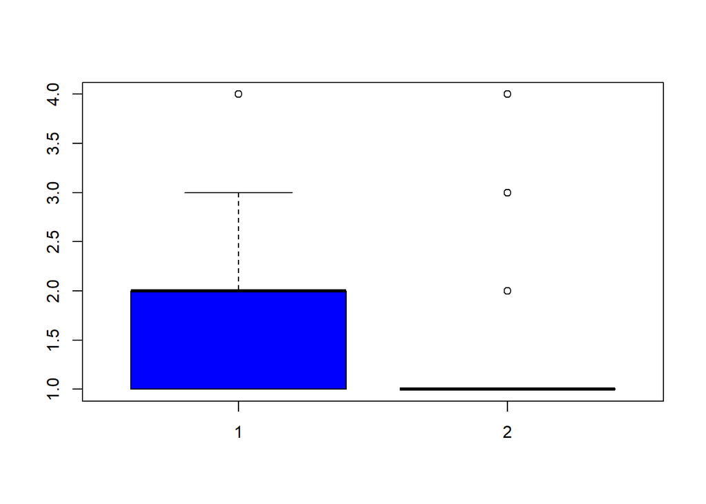

```r
#The next few visualizations are used for understanding relationship between mobile phone access and mobile money market usage
boxplot(GFIMobileData$GFI.Mobile.phone.payments.usage,GFIMobileData$GFI.mobileowne,col="blue")
```

```r
# Activate likert and plyr

library(likert)
```

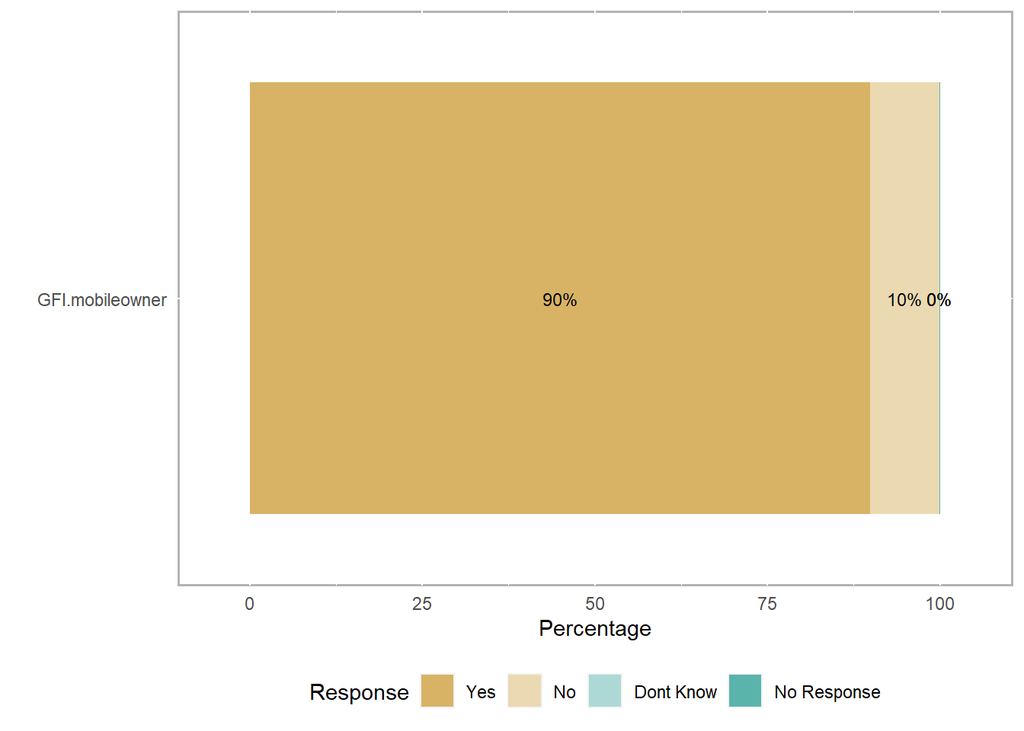

```r
library(plyr)

# Select only the first 8 items in the survey
items <- select(GFIMobileData, starts_with(c("GFI.mobileowner")))

# A custom function to recode numerical responses into ordered factors
likert_recode <- function(x) {
  y <- ifelse(is.na(x), NA,
              ifelse(x == 1, "Yes",
                     ifelse(x == 2, "No",
                            ifelse(x == 3, "Dont Know", "No Response"))))

  y <- factor(y, levels = c("Yes", "No", "Dont Know", "No Response"))

  return(y)
}

# Transform the items into factors and save the data set as a likert object
items_likert <- items %>%
  mutate_all(likert_recode) %>%
  likert()

# Create a stacked bar chart
plot(items_likert,
     # Group the items alphabetically
     group.order=names(items),
     # Plot the percentages for each response category
     plot.percents = TRUE,
     # Plot the total percentage for negative responses
     plot.percent.low = FALSE,
     # Plot the total percentage for positive responses
     plot.percent.high = FALSE,
     # Whether response categories should be centered
     # This is only helpful when there is a middle response
     # option such as "neutral" or "neither agree nor disagree"
     centered = FALSE,
     # Wrap label text for item labels
     wrap=30)
```

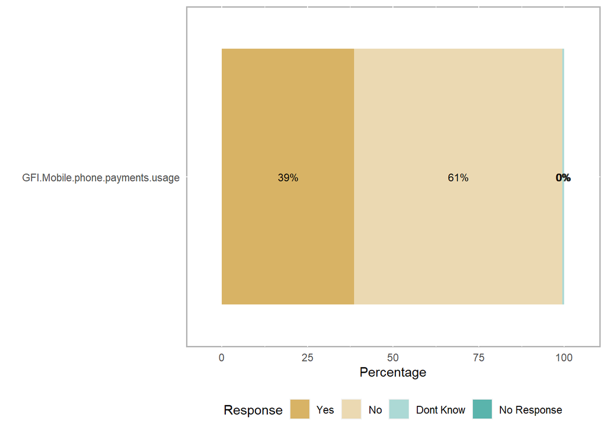

```r
# Activate likert and plyr

library(likert)
library(plyr)

# Select only the first 8 items in the survey
items <- select(GFIMobileData, starts_with(c("GFI.Mobile.phone.payments.usage")))

# A custom function to recode numerical responses into ordered factors
likert_recode <- function(x) {
  y <- ifelse(is.na(x), NA,
              ifelse(x == 1, "Yes",
                     ifelse(x == 2, "No",
                            ifelse(x == 3, "Dont Know", "No Response"))))

  y <- factor(y, levels = c("Yes", "No", "Dont Know", "No Response"))

  return(y)
}

# Transform the items into factors and save the data set as a likert object
items_likert <- items %>%
  mutate_all(likert_recode) %>%
  likert()

# Create a stacked bar chart
plot(items_likert,
     # Group the items alphabetically
     group.order=names(items),
     # Plot the percentages for each response category
     plot.percents = TRUE,
     # Plot the total percentage for negative responses
     plot.percent.low = FALSE,
     # Plot the total percentage for positive responses
     plot.percent.high = FALSE,
     # Whether response categories should be centered
     # This is only helpful when there is a middle response
     # option such as "neutral" or "neither agree nor disagree"
     centered = FALSE,
     # Wrap label text for item labels
     wrap=30)
```

This initial, basic visualization above show how the chunk of the responses represent how most people own a mobile phone and may also utilize mobile payments as one of their financial services options.However, the %age of people owning a mobile phone compared to those actually utilizing mobile payments is much higher. This will be further explored later on where we try to understand reasons for individuals to not opt for advanced methods of financial services.

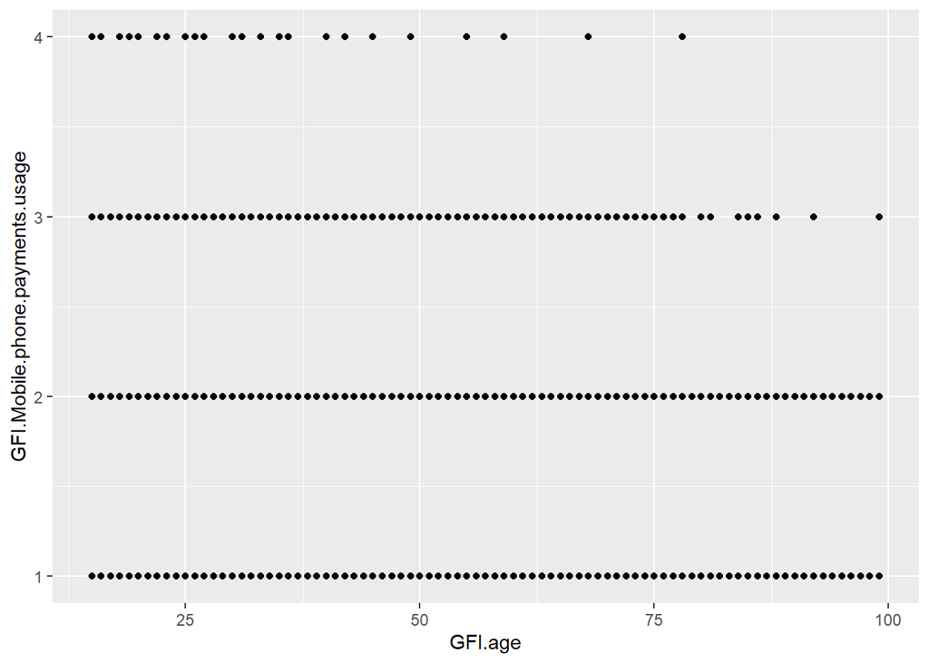

```r
#Seeing how mobile money mode usage varies with age
cbPalette <-c("orange","green")
MP.plot <- ggplot(data=GFIMobileData
                  , aes(x=GFI.age
                        , y=GFI.Mobile.phone.payments.usage))
ggplot(data=GFIMobileData
       , aes(y=GFI.Mobile.phone.payments.usage, x=GFI.age))+geom_point(aes())+scale_colour_manual(values = cbPalette)
```

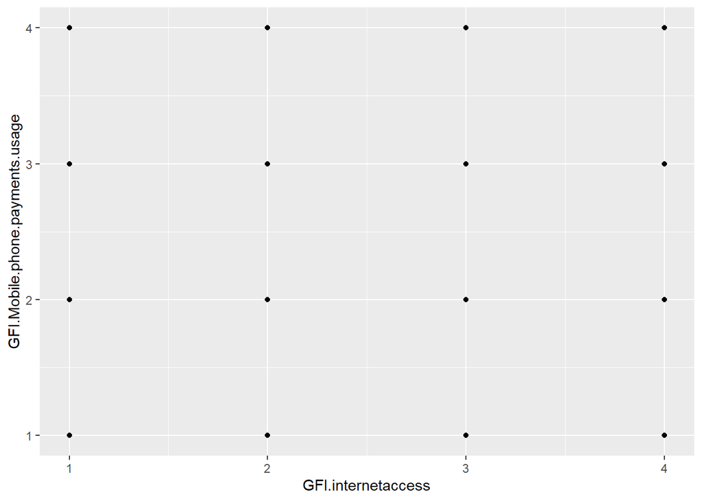

```r
#Seeing how internet access influences use of mobile money market
cbPalette <-c("orange","green")
MP.plot <- ggplot(data=GFIMobileData
                  , aes(x=GFI.internetaccess
                        , y=GFI.Mobile.phone.payments.usage))
ggplot(data=GFIMobileData
       , aes(y=GFI.Mobile.phone.payments.usage, x=GFI.internetaccess))+geom_point(aes())+scale_colour_manual(values = cbPalette)
```

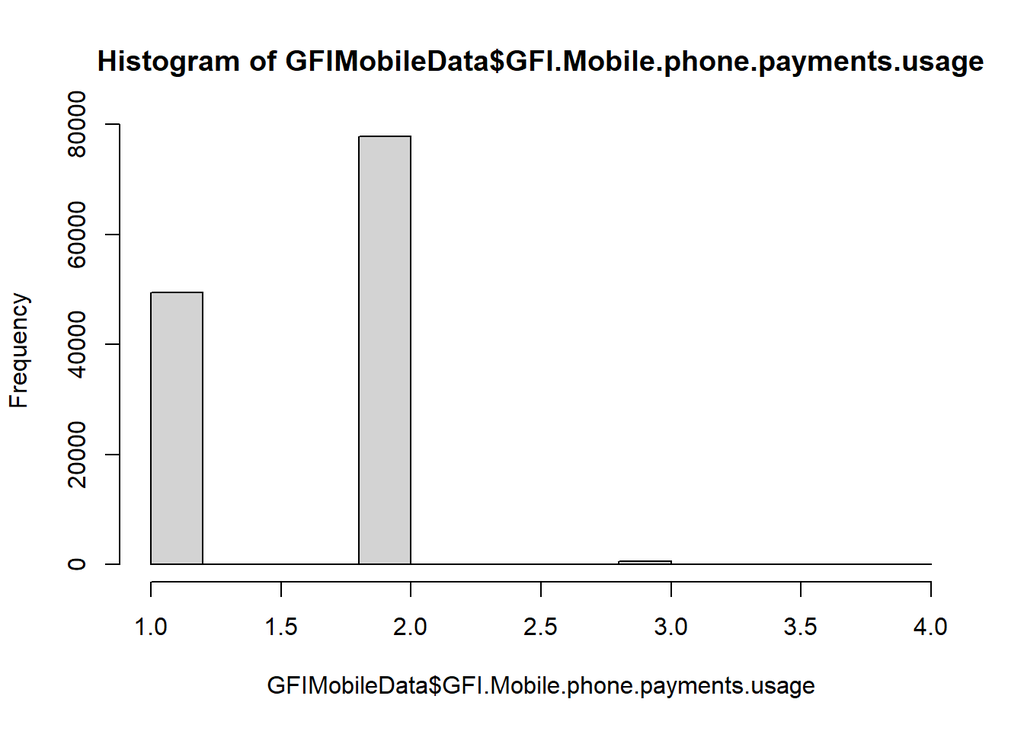

```r
hist(GFIMobileData$GFI.Mobile.phone.payments.usage)
```

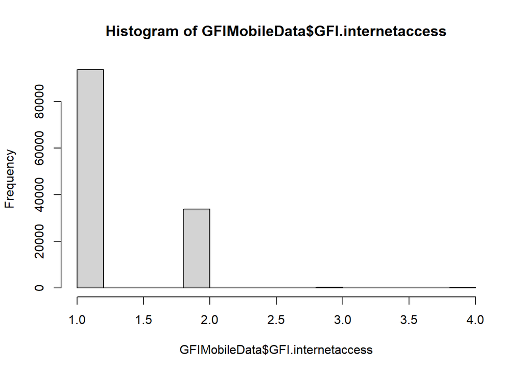

```r
hist(GFIMobileData$GFI.internetaccess)
```

We notice how despite a greater share of respondents showing access to internet, there is not as much mobile money market utilization by individuals. Therefore, internet access or lack there of may not be the only factor impacting success or failure of mobile money markets.

## Reasons that prevent financial inclusion/utilization of financial services

We now divert our focus on factors that act as a hindrance for people to opt for financial services usage and later we shall utilize our analysis to understand how can we counter some of these obstacles to encourage financial inclusion.

```r
GFIObstacles<- data.frame(GFI$Country,GFI$Region,GFI$age,GFI$Gender,GFI$pop_adult,GFI$Bank.Account.Ownership,GFI$Debit.ATM.Card.Ownership,GFI$Independency.in.bank.account.usage,GFI$FI.is.far,GFI$FS.expensive,GFI$Dont.have.documentation,GFI$Don.t.trust.FI,GFI$Religious,GFI$Not.enough.money,GFI$Use.family.members.account,GFI$No.need.of.FS)
```

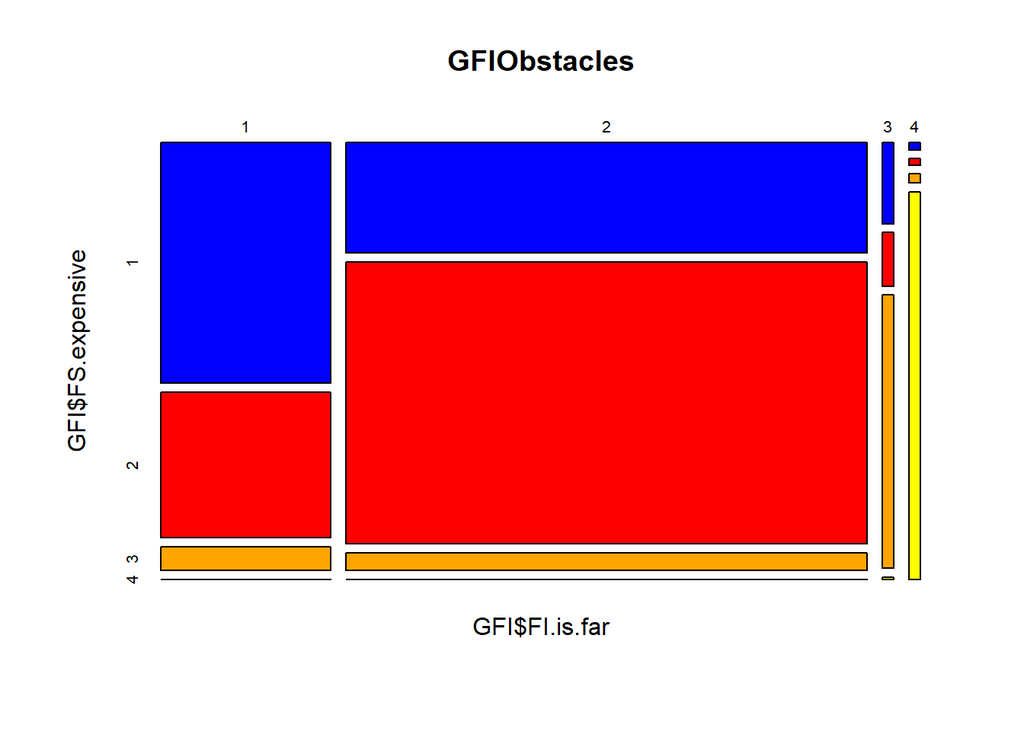

```r
#Ranking different obstacles in accessing/using
mosaicplot(GFI$FI.is.far~
           GFI$FS.expensive
           ,data=GFIObstacles
           ,col=c("Blue","Red","Orange","Yellow"))
```

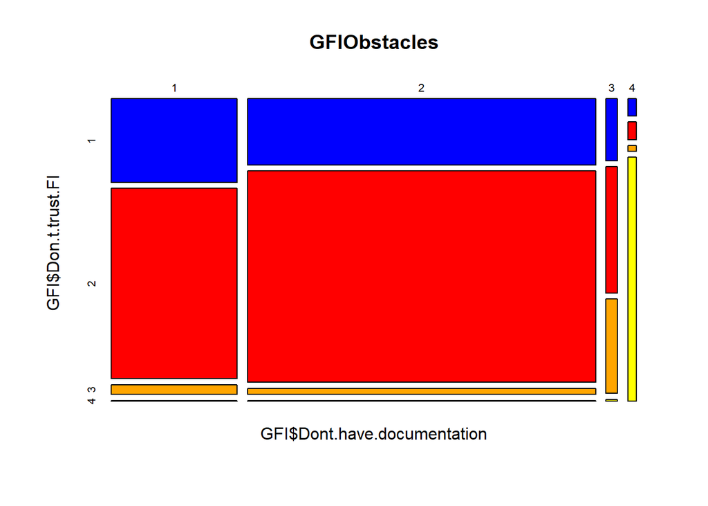

```r
mosaicplot(GFI$Dont.have.documentation~
           GFI$Don.t.trust.FI
           ,data=GFIObstacles
           ,col=c("Blue","Red","Orange","Yellow"))
```

The mosaic plots represent the following key obstacles: 1) The first mosaic plot shows how people perceive financial services to be expenses and how for some financial institutions are too far to access. 2) The second mosaic plot shows how certain individuals don’t trust these financial institutions or lack the relevant documentation required to become part of financial institutions or utilize financial services.

One can assume that this would be a case in developing countries, specifically in rural areas where financial institutions may not be found as easily due to lower demand for such services.Furthermore, the lack of trust may come from lack of exposure to financial institutions but also could be rooted in how advancing financial services like mobile or internet banking is more prone to scams therefore, people are not as comfortable utilizing them just as yet.

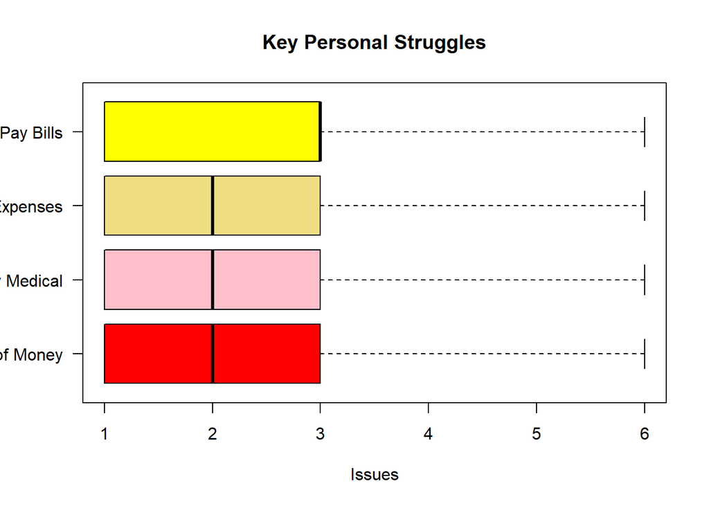

```r
boxplot (GFI$Lack.of.money.in.old.age,GFI$Not.be.able.to.pay.for.medical,GFI$Not.able.to.pay.for.monthly.expenses,GFI$Not.pay.bills.fees,
         horizontal = TRUE,
         main = "Key Personal Struggles",
         xlab = "Issues",
         ylab = "",
         col = c("red","pink","lightgoldenrod","yellow","lightblue","blue"))
axis(2,at=1:4,labels=c("Lack of Money","Not Pay Medical","Not Pay Expenses","Not Pay Bills"), las=2)
```

This graph helps us identify how many individuals are engrossed in key financial struggles therefore, opting for financial services is an alien concept for them as they have other pressing issues to worry about.

## Linear analysis between some factors and digital financial services

```r
#linear model to analyze relationship between bank account and population
GFIbs.lmfit <- lm(Bank.Account.Ownership ~ pop_adult, data=GFI)
summary(GFIbs.lmfit)
```

```
##
## Call:
## lm(formula = Bank.Account.Ownership ~ pop_adult, data = GFI)
##
## Residuals:
##     Min      1Q  Median      3Q     Max
## -0.5218 -0.4503 -0.4498  0.5494  2.5503
##
## Coefficients:
##              Estimate Std. Error t value Pr(>|t|)
## (Intercept) 1.450e+00  1.505e-03  963.42   <2e-16 ***
## pop_adult   6.259e-11  5.988e-12   10.45   <2e-16 ***
## ---
## Signif. codes:  0 '***' 0.001 '**' 0.01 '*' 0.05 '.' 0.1 ' ' 1
##
## Residual standard error: 0.5096 on 127852 degrees of freedom
## Multiple R-squared:  0.0008537,  Adjusted R-squared:  0.0008459
## F-statistic: 109.2 on 1 and 127852 DF,  p-value: < 2.2e-16
```

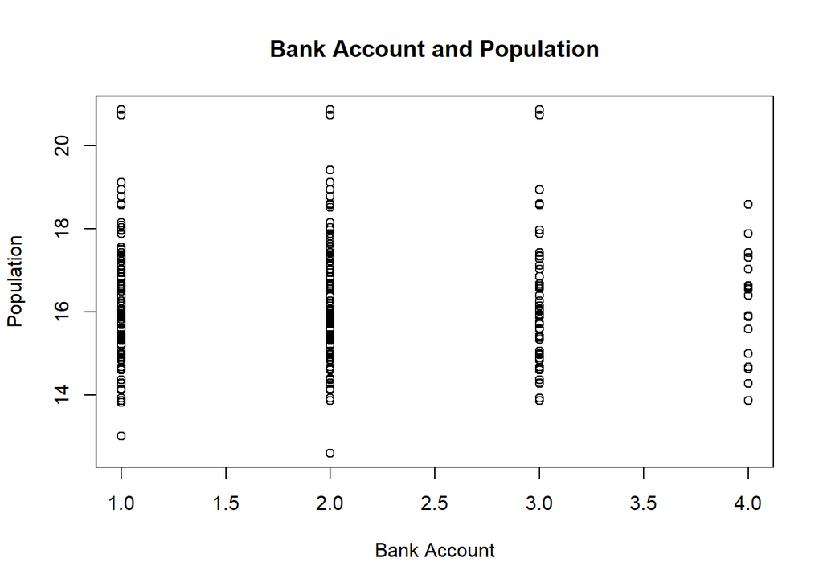

```r
plot (log(GFI$pop_adult)~as.numeric(GFI$Bank.Account.Ownership),
      ylab = "Population",
      xlab = "Bank Account",
      main = "Bank Account and Population")
abline(GFIbs.lmfit, col="red")
```

```r
#linear model to analyze relationship between debit card and population
GFcbs.lmfit <- lm(Debit.ATM.Card.Ownership ~ pop_adult, data=GFI)
summary(GFcbs.lmfit)
```

```
##
## Call:
## lm(formula = Debit.ATM.Card.Ownership ~ pop_adult, data = GFI)
##
## Residuals:
##     Min      1Q  Median      3Q     Max
## -0.4705 -0.4698 -0.4591  0.5302  2.6212
##
## Coefficients:
##               Estimate Std. Error t value Pr(>|t|)
## (Intercept)  1.471e+00  1.548e-03  950.01   <2e-16 ***
## pop_adult   -7.952e-11  6.160e-12  -12.91   <2e-16 ***
## ---
## Signif. codes:  0 '***' 0.001 '**' 0.01 '*' 0.05 '.' 0.1 ' ' 1
##
## Residual standard error: 0.5243 on 127852 degrees of freedom
## Multiple R-squared:  0.001302,   Adjusted R-squared:  0.001294
## F-statistic: 166.6 on 1 and 127852 DF,  p-value: < 2.2e-16
```

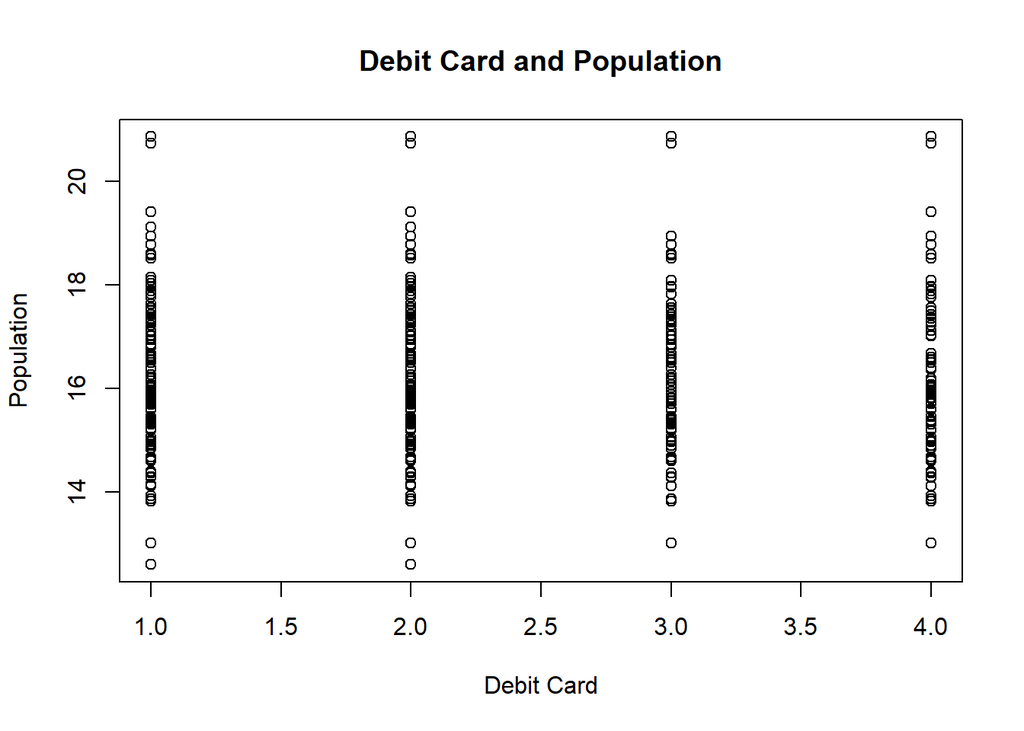

```r
plot (log(GFI$pop_adult)~as.numeric(GFI$Debit.ATM.Card.Ownership),
      ylab = "Population",
      xlab = "Debit Card",
      main = "Debit Card and Population")
abline(GFIbs.lmfit, col="red")
```

## Conclusion

Following are the key takeaways: Encourage Mobile Money Market Financial Services: - It is evident that majority of the communities own a mobile phone and therefore, introduction of mobile money market financial services can be a key advancement in terms of financial services that may be utilized within these communities - In communities where this is already been introduced more focused awareness campaigns must be done to encourage adoption of this model

Address key concerns to encourage financial inclusion - Issues like trust in financial services can be easily addressed through better awareness campaigns - educating individuals on how financial service benefits outweigh the costs and risk associated with them is key in this progress - Identify areas with limited or no financial services - this will encourage financial inclusion, especially in low to mid-income regions - Educate individuals how opting for financial services encourages savings and investment and therefore, would aid in resolving their financial struggles overtime

Encouraging financing inclusion - this is a key step as this directly correlates with economic progress and development. Small and medium enterprises or microfinancing financial services are key building blocks within low-income communities. By encouraging financial inclusion, we open up newer emplpoyment avenues for these communities.

## References

1. Refered to Lecture Slides for different codes
2. https://towardsdatascience.com/5-ways-to-effectively-visualize-survey-data-using-r-89928bf08cb2
3. https://stackoverflow.com/questions/13297995/changing-font-size-and-direction-of-axes-text-in-ggplot2